# Does trap type matter?

January 31 2018

# Univariate analyses

See whether greater variance in bait type or trap type?

## Species richness

```r
lmdata<- read.csv("/Users/mbrown/Documents/Oxford by Year/PROJECT (and stuff)/Analysis/Analysis excel/Linear Model/Linear Model Analysis Trap Type.csv")
lmdata$Block <- rep(1:8, 11)
head(lmdata)
```

|  | Site | Bait.Type | Trap.Type | Abundance | Richness | Diversity | Block |
| --- | --- | --- | --- | --- | --- | --- | --- |
| 1 | LIBO | Human | Standard 25g Human | 437 | 8 | 1.285520 | 1 |
| 2 | ROKAN | Human | Standard 25g Human | 169 | 7 | 1.295516 | 2 |
| 3 | LIBO | Human | Standard 25g Human | 63 | 5 | 1.182567 | 3 |
| 4 | ROKAN | Human | Standard 25g Human | 82 | 7 | 1.432127 | 4 |
| 5 | LIBO | Human | Standard 25g Human | 383 | 9 | 1.748631 | 5 |
| 6 | ROKAN | Human | Standard 25g Human | 306 | 6 | 1.001611 | 6 |

```r
lmdata$Trap.Type<- relevel(lmdata$Trap.Type, "Standard 25g Human")
lmdata$Block<- as.factor(lmdata$Block)
options(scipen=999)

meansandsd <- function(data, y = group){
  meantable <- rep(NA, dim(data)[2])
  sdtable <- rep(NA, dim(data)[2])

  for(i in 1:dim(data)[2]){
    if(anyNA(data[,i]) == TRUE){
      data<-data[complete.cases(data[,i]),]
    } else data[,i]
    meantable[i] <- data.frame(tapply(data[,i], INDEX = data[, y], FUN = mean))
    sdtable[i] <- data.frame(tapply(data[,i], INDEX = data[, y], FUN = function(x) sd(x)/sqrt(length(x))))
  }

  tables<-cbind(data.frame(unlist(c(meantable))), data.frame(unlist(c(sdtable))))
  tables$Group <- rep(levels(data[, y]), length(names(data)))
  tables$Trait <- rep(names(data), each = length(levels(data[, y])))
  #tables2 <- tables[-c(1:length(levels(data[, y]))),]
  tables2 <- tables[tables$Trait != y,]
  colnames(tables2)[1] <- "Mean"
  colnames(tables2)[2] <- "SEM"
  tables2
}

# calculate means and standard errors
meansandsd(lmdata, y = "Trap.Type")
```

[output not shown]

[output not shown]

[output not shown]

[output not shown]

[output not shown]

[output not shown]

[output not shown]

[output not shown]

|  | Mean | SEM | Group | Trait |
| --- | --- | --- | --- | --- |
| 1 | NA | 0.18898224 | Standard 25g Human | Site |
| 2 | NA | 0.18898224 | 25g Human Bowl | Site |
| 3 | NA | 0.18898224 | 25g Human Grid (2cm) | Site |
| 4 | NA | 0.18898224 | 700g Cattle Bowl | Site |
| 5 | NA | 0.18898224 | 700g Cattle Grid (2cm) | Site |
| 6 | NA | 0.18898224 | FIT 1 Week | Site |
| 7 | NA | 0.18898224 | FIT 24h | Site |
| 8 | NA | 0.18898224 | Live 25g Human | Site |
| 9 | NA | 0.18898224 | Live 700g Cattle | Site |
| 10 | NA | 0.18898224 | Standard 50g Cattle | Site |

[output cut: 56 more lines]

Richness is nothing fancy here, it is just raw numbers of species per trap. The model below is the same model in general to the models that follow. I have put in a random effect of site, to take into account the differences between ROKAN and LIBO. I have also added in “block” to take into account block to block variability. The residuals are modelled by a poisson distribution because the data is count data.

The anova shows that adding in trap type to the model is significant in explaining the variation. Not sure if this is useful!

```r
library(lme4)
fmtrap1.1<- glmer(Richness ~ 1 + Trap.Type + (1|Site) + (1 | Block), data = lmdata, family = "poisson")

summary(fmtrap1.1)
```

```
## Generalized linear mixed model fit by maximum likelihood (Laplace
##   Approximation) [glmerMod]
##  Family: poisson  ( log )
## Formula: Richness ~ 1 + Trap.Type + (1 | Site) + (1 | Block)
##    Data: lmdata
##
##      AIC      BIC   logLik deviance df.resid
##    398.4    430.6   -186.2    372.4       75
##
## Scaled residuals:
##     Min      1Q  Median      3Q     Max
## -1.5748 -0.5567 -0.1000  0.4682  2.6064
##
## Random effects:
##  Groups Name        Variance Std.Dev.
##  Block  (Intercept) 0        0
##  Site   (Intercept) 0        0
## Number of obs: 88, groups:  Block, 8; Site, 2
##
## Fixed effects:
##                                 Estimate Std. Error z value
## (Intercept)                      2.04769    0.12700  16.124
## Trap.Type25g Human Bowl         -0.43825    0.20280  -2.161
## Trap.Type25g Human Grid (2cm)    0.09237    0.17560   0.526
## Trap.Type700g Cattle Bowl        0.19035    0.17165   1.109
## Trap.Type700g Cattle Grid (2cm)  0.13555    0.17382   0.780
## Trap.TypeFIT 1 Week             -0.34294    0.19712  -1.740
## Trap.TypeFIT 24h                -1.48808    0.29590  -5.029
## Trap.TypeLive 25g Human         -0.19531    0.18904  -1.033
## Trap.TypeLive 700g Cattle       -0.21511    0.19008  -1.132
## Trap.TypeStandard 50g Cattle    -0.29849    0.19460  -1.534
## Trap.TypeStandard 700g Cattle    0.10697    0.17499   0.611
##                                             Pr(>|z|)
## (Intercept)                     < 0.0000000000000002 ***
## Trap.Type25g Human Bowl                       0.0307 *
## Trap.Type25g Human Grid (2cm)                 0.5989
## Trap.Type700g Cattle Bowl                     0.2674
## Trap.Type700g Cattle Grid (2cm)               0.4355
## Trap.TypeFIT 1 Week                           0.0819 .
## Trap.TypeFIT 24h                         0.000000493 ***
```

[output cut: 15 more lines]

```
## Trp.TypL25H -0.672  0.421  0.486  0.497  0.491  0.433  0.288
## Trp.TyL700C -0.668  0.418  0.483  0.494  0.488  0.430  0.287  0.449
## Trp.TypS50C -0.653  0.409  0.472  0.483  0.477  0.420  0.280  0.438  0.436
## Trp.TyS700C -0.726  0.454  0.525  0.537  0.530  0.468  0.311  0.488  0.485
##             T.TS5C
## Trp.Typ25HB
## Tr.T25HG(2)
## Trp.Ty700CB
## T.T700CG(2)
## Trp.TyFIT1W
## Trp.TyFIT24
## Trp.TypL25H
## Trp.TyL700C
## Trp.TypS50C
## Trp.TyS700C  0.474
```

```r
anova(fmtrap1.1)
```

|  | Df | Sum Sq | Mean Sq | F value |
| --- | --- | --- | --- | --- |
| Trap.Type | 10 | 53.31361 | 5.331361 | 5.331361 |

```r
1-pt(df = 10, q = 5.3314)
```

```
## [1] 0.0001661482
```

```r
fmtrap1.2<- glmer(Richness ~ 1 + (1|Site) + (1 | Block), data = lmdata, family = "poisson")
anova(fmtrap1.1, fmtrap1.2)
```

|  | Df | AIC | BIC | logLik | deviance | Chisq | Chi Df | Pr(>Chisq) |
| --- | --- | --- | --- | --- | --- | --- | --- | --- |
| fmtrap1.2 | 3 | 448.7506 | 456.1826 | -221.3753 | 442.7506 | NA | NA | NA |
| fmtrap1.1 | 13 | 398.4344 | 430.6398 | -186.2172 | 372.4344 | 70.31617 | 10 | 0.00000000003852229 |

Slightly re-vamped plot, that has been plotted many, many times…

```r
library(reshape2)
meltdata<- melt(lmdata, id.vars = c("Site", "Bait.Type", "Trap.Type"))
library(plyr)
meltdata$value <- as.numeric(meltdata$value)
standarderrordata<-ddply(meltdata, c("Trap.Type", "Bait.Type", "variable"), summarise,
                       N= length(variable) ,
                       mean= mean(value, na.rm=TRUE),
                       sd= sd(value),
                       sem =sd(value)/sqrt(length(value)))
library(dplyr)
```

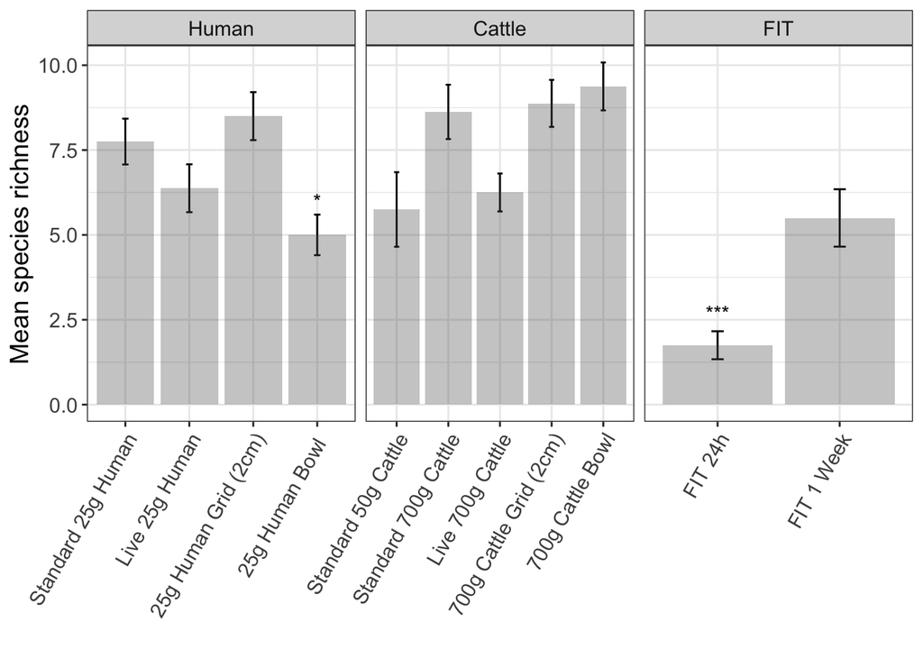

```r
abundancedata<- filter(standarderrordata, standarderrordata$variable == "Abundance")
richnessdata<- filter(standarderrordata, standarderrordata$variable == "Richness")
diversitydata<- filter(standarderrordata, standarderrordata$variable == "Diversity")

richnessdata$Trap.Type <- factor(richnessdata$Trap.Type, levels=c("Standard 25g Human","Live 25g Human","25g Human Grid (2cm)","25g Human Bowl ","Standard 50g Cattle", "Standard 700g Cattle","Live 700g Cattle","700g Cattle Grid (2cm)","700g Cattle Bowl", "FIT 24h", "FIT 1 Week"))
richnessdata$Bait.Type<- factor(richnessdata$Bait.Type, levels=c("Human", "Cattle", "FIT"))

ann_text4<- data.frame(Trap.Type = c(4), mean = c(6), lab = "*",
                       Bait.Type = factor("Human",levels = c("Human","Cattle","FIT")))
ann_text5<- data.frame(Trap.Type = c(1), mean = c(2.7), lab = "***",
                       Bait.Type = factor("FIT",levels = c("Human","Cattle","FIT")))

library(ggplot2)
ggplot(richnessdata, aes(x=Trap.Type, y=mean, fill = NULL))+
  geom_errorbar(aes(ymin = mean - sem, ymax = mean + sem), width = 0.1)+
  #geom_point(col = "black")+
  theme_bw() +
  theme(axis.text.x = element_text(angle = 60, hjust = 1))+
  facet_grid(.~Bait.Type, scales = "free", as.table=FALSE)+
  geom_bar(stat="identity", alpha=1/3)+
  labs(x="", y="Mean species richness")+
  scale_fill_discrete(name="Bait Type")+
  theme(text = element_text(size=14))+
  geom_text(data = ann_text4 ,label = "*")+
  geom_text(data = ann_text5 ,label = "***")
```

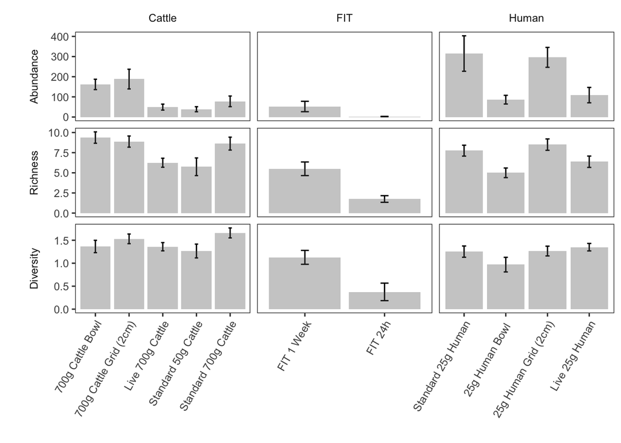

```r
# get rid of block and plot all together?
standarderrordata2 <- standarderrordata[standarderrordata$variable != "Block", ]
ggplot(standarderrordata2, aes(x= Trap.Type, y=mean))+
  geom_errorbar(aes(ymin = mean - sem, ymax = mean + sem), width = 0.1)+
  theme_bw()+
  geom_bar(stat = "identity", alpha = 1/3)+
  facet_grid(variable~Bait.Type, scales = "free", switch = "y")+
  theme(axis.text.x = element_text(hjust = 1, angle = 60),
        legend.position = "none",
        strip.background = element_rect(fill = "white", colour="white"),
        strip.text.y = element_text(),
        strip.placement = "outside",
        panel.grid = element_blank())+
  ylab(label = "")+
  xlab(label = "")
```

## Beetle abundance

```r
fmtrap2.1 <- lmer(log(Abundance) ~ Trap.Type + (1 | Site) + (1 | Block), data = lmdata)
summary(fmtrap2.1)
```

```
## Linear mixed model fit by REML ['lmerMod']
## Formula: log(Abundance) ~ Trap.Type + (1 | Site) + (1 | Block)
##    Data: lmdata
##
## REML criterion at convergence: 220.1
##
## Scaled residuals:
##      Min       1Q   Median       3Q      Max
## -2.32110 -0.67289 -0.02312  0.58748  2.20212
##
## Random effects:
##  Groups   Name        Variance              Std.Dev.
##  Block    (Intercept) 0.0774996854187781636 0.27838765314
##  Site     (Intercept) 0.0000000000000001269 0.00000001127
##  Residual             0.7059627954600512512 0.84021592193
## Number of obs: 88, groups:  Block, 8; Site, 2
##
## Fixed effects:
##                                 Estimate Std. Error t value
## (Intercept)                       5.4579     0.3129  17.440
## Trap.Type25g Human Bowl          -1.1811     0.4201  -2.812
## Trap.Type25g Human Grid (2cm)     0.1127     0.4201   0.268
## Trap.Type700g Cattle Bowl        -0.4503     0.4201  -1.072
## Trap.Type700g Cattle Grid (2cm)  -0.5015     0.4201  -1.194
## Trap.TypeFIT 1 Week              -2.2097     0.4201  -5.260
## Trap.TypeFIT 24h                 -4.8873     0.4201 -11.633
## Trap.TypeLive 25g Human          -1.1736     0.4201  -2.793
## Trap.TypeLive 700g Cattle        -1.8851     0.4201  -4.487
## Trap.TypeStandard 50g Cattle     -2.2316     0.4201  -5.312
## Trap.TypeStandard 700g Cattle    -1.5592     0.4201  -3.711
##
## Correlation of Fixed Effects:
##             (Intr) T.T2HB T.THG( T.T7CB T.TCG( T.TF1W T.TFI2 T.TL2H T.TL7C
## Trp.Typ25HB -0.671
## Tr.T25HG(2) -0.671  0.500
## Trp.Ty700CB -0.671  0.500  0.500
## T.T700CG(2) -0.671  0.500  0.500  0.500
## Trp.TyFIT1W -0.671  0.500  0.500  0.500  0.500
## Trp.TyFIT24 -0.671  0.500  0.500  0.500  0.500  0.500
## Trp.TypL25H -0.671  0.500  0.500  0.500  0.500  0.500  0.500
## Trp.TyL700C -0.671  0.500  0.500  0.500  0.500  0.500  0.500  0.500
## Trp.TypS50C -0.671  0.500  0.500  0.500  0.500  0.500  0.500  0.500  0.500
## Trp.TyS700C -0.671  0.500  0.500  0.500  0.500  0.500  0.500  0.500  0.500
##             T.TS5C
## Trp.Typ25HB
## Tr.T25HG(2)
## Trp.Ty700CB
## T.T700CG(2)
## Trp.TyFIT1W
## Trp.TyFIT24
## Trp.TypL25H
## Trp.TyL700C
## Trp.TypS50C
## Trp.TyS700C  0.500
```

```r
fmtrap2.2 <- lmer(log(Abundance) ~ 1 + (1 | Site) + (1 | Block), data = lmdata)

anova(fmtrap2.2, fmtrap2.1)
```

```
## refitting model(s) with ML (instead of REML)
```

|  | Df | AIC | BIC | logLik | deviance | Chisq | Chi Df | Pr(>Chisq) |
| --- | --- | --- | --- | --- | --- | --- | --- | --- |
| fmtrap2.2 | 4 | 337.8454 | 347.7547 | -164.9227 | 329.8454 | NA | NA | NA |
| fmtrap2.1 | 14 | 241.6766 | 276.3593 | -106.8383 | 213.6766 | 116.1688 | 10 | 0.00000000000000000003024926 |

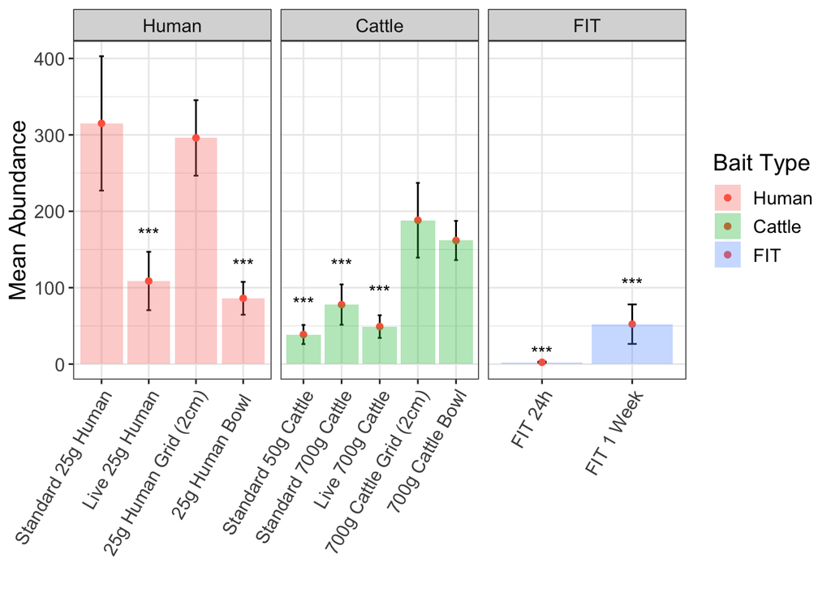

```r
abundancedata$Trap.Type <- factor(abundancedata$Trap.Type, levels=c("Standard 25g Human","Live 25g Human","25g Human Grid (2cm)","25g Human Bowl ","Standard 50g Cattle", "Standard 700g Cattle","Live 700g Cattle","700g Cattle Grid (2cm)","700g Cattle Bowl", "FIT 24h", "FIT 1 Week"))
abundancedata$Bait.Type<- factor(abundancedata$Bait.Type, levels=c("Human", "Cattle", "FIT"))
ann_text1 <- data.frame(Trap.Type = c(2,4), mean = c(170, 130), lab = "***",
                        Bait.Type = factor("Human",levels = c("Human","Cattle","FIT")))
ann_text2<-  data.frame(Trap.Type = c(1,2,3), mean = c(80, 130, 95), lab = "***",
                        Bait.Type = factor("Cattle",levels = c("Human","Cattle","FIT")))
ann_text3<- data.frame(Trap.Type = c(1,2), mean = c(15, 105), lab = "***",
                       Bait.Type = factor("FIT",levels = c("Human","Cattle","FIT")))

ggplot(abundancedata, aes(x=Trap.Type, y=mean, fill = Bait.Type))+
  geom_errorbar(aes(ymin = mean - sem, ymax = mean + sem), width = 0.1)+
  geom_point(col = "tomato")+
  theme_bw() +
  theme(axis.text.x = element_text(angle = 60, hjust = 1))+
  facet_grid(.~Bait.Type, scales = "free", as.table=FALSE)+
  ylab("Mean Abundance")+
  geom_bar(stat="identity", alpha=1/3)+
  labs(x="", y="Mean Abundance")+
  scale_fill_discrete(name="Bait Type")+
  theme(text = element_text(size=14))+
  geom_text(data = ann_text1 ,label = "***")+
  geom_text(data = ann_text2, label = "***")+
  geom_text(data = ann_text3, label = "***")
```

## Shannon Diversity of beetles

Model specification as above. Random effects as above. Fixed effects show a significant decrease in diversity in the 24h FIT, and a significant increase in diversity in the standard 700g cattle baited pitfall traps. I think the correlation of fixed effects can be ignored.

```r
fmtrap3.1<- lmer(Diversity ~ Trap.Type + (1 | Site) + (1 | Block), data = lmdata)
summary(fmtrap3.1)
```

```
## Linear mixed model fit by REML ['lmerMod']
## Formula: Diversity ~ Trap.Type + (1 | Site) + (1 | Block)
##    Data: lmdata
##
## REML criterion at convergence: 83.6
##
## Scaled residuals:
##      Min       1Q   Median       3Q      Max
## -2.18229 -0.63183 -0.00035  0.58965  2.28744
##
## Random effects:
##  Groups   Name        Variance              Std.Dev.
##  Block    (Intercept) 0.0204816615602766983 0.1431141557
##  Site     (Intercept) 0.0000000000000003762 0.0000000194
##  Residual             0.1167845053402324501 0.3417374802
## Number of obs: 88, groups:  Block, 8; Site, 2
##
## Fixed effects:
##                                 Estimate Std. Error t value
## (Intercept)                      1.25234    0.13099   9.561
## Trap.Type25g Human Bowl         -0.28337    0.17087  -1.658
## Trap.Type25g Human Grid (2cm)    0.01228    0.17087   0.072
## Trap.Type700g Cattle Bowl        0.11146    0.17087   0.652
## Trap.Type700g Cattle Grid (2cm)  0.27810    0.17087   1.628
## Trap.TypeFIT 1 Week             -0.12490    0.17087  -0.731
## Trap.TypeFIT 24h                -0.87674    0.17087  -5.131
## Trap.TypeLive 25g Human          0.09655    0.17087   0.565
## Trap.TypeLive 700g Cattle        0.10656    0.17087   0.624
## Trap.TypeStandard 50g Cattle     0.01312    0.17087   0.077
## Trap.TypeStandard 700g Cattle    0.40684    0.17087   2.381
##
## Correlation of Fixed Effects:
##             (Intr) T.T2HB T.THG( T.T7CB T.TCG( T.TF1W T.TFI2 T.TL2H T.TL7C
## Trp.Typ25HB -0.652
## Tr.T25HG(2) -0.652  0.500
## Trp.Ty700CB -0.652  0.500  0.500
## T.T700CG(2) -0.652  0.500  0.500  0.500
## Trp.TyFIT1W -0.652  0.500  0.500  0.500  0.500
## Trp.TyFIT24 -0.652  0.500  0.500  0.500  0.500  0.500
## Trp.TypL25H -0.652  0.500  0.500  0.500  0.500  0.500  0.500
## Trp.TyL700C -0.652  0.500  0.500  0.500  0.500  0.500  0.500  0.500
## Trp.TypS50C -0.652  0.500  0.500  0.500  0.500  0.500  0.500  0.500  0.500
## Trp.TyS700C -0.652  0.500  0.500  0.500  0.500  0.500  0.500  0.500  0.500
##             T.TS5C
## Trp.Typ25HB
## Tr.T25HG(2)
## Trp.Ty700CB
## T.T700CG(2)
## Trp.TyFIT1W
## Trp.TyFIT24
## Trp.TypL25H
## Trp.TyL700C
## Trp.TypS50C
## Trp.TyS700C  0.500
```

```r
fmtrap3.2<- lmer(Diversity ~ 1 + (1 | Site) + (1 | Block), data = lmdata)
anova(fmtrap3.1, fmtrap3.2)
```

```
## refitting model(s) with ML (instead of REML)
```

|  | Df | AIC | BIC | logLik | deviance | Chisq | Chi Df | Pr(>Chisq) |
| --- | --- | --- | --- | --- | --- | --- | --- | --- |
| fmtrap3.2 | 4 | 125.35838 | 135.2677 | -58.67919 | 117.35838 | NA | NA | NA |
| fmtrap3.1 | 14 | 85.60681 | 120.2895 | -28.80340 | 57.60681 | 59.75157 | 10 | 0.000000004038489 |

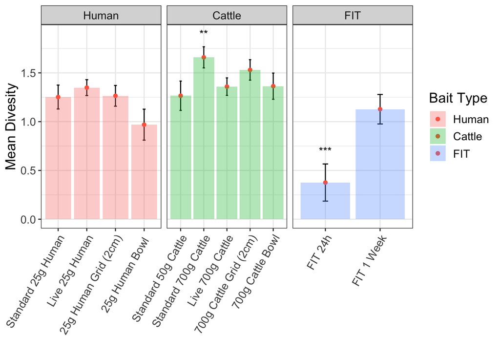

```r
diversitydata$Trap.Type <- factor(abundancedata$Trap.Type, levels=c("Standard 25g Human","Live 25g Human","25g Human Grid (2cm)","25g Human Bowl ","Standard 50g Cattle", "Standard 700g Cattle","Live 700g Cattle","700g Cattle Grid (2cm)","700g Cattle Bowl", "FIT 24h", "FIT 1 Week"))
diversitydata$Bait.Type<- factor(abundancedata$Bait.Type, levels=c("Human", "Cattle", "FIT"))

ann_text6 <- data.frame(Trap.Type = c(2), mean = c(1.9), lab = "**",
                        Bait.Type = factor("Cattle",levels = c("Human","Cattle","FIT")))
ann_text7 <-  data.frame(Trap.Type = c(1), mean = c(0.7), lab = "***",
                        Bait.Type = factor("FIT",levels = c("Human","Cattle","FIT")))

ggplot(diversitydata, aes(x=Trap.Type, y=mean, fill = Bait.Type))+
  geom_errorbar(aes(ymin = mean - sem, ymax = mean + sem), width = 0.1)+
  geom_point(col = "tomato")+
  theme_bw() +
  theme(axis.text.x = element_text(angle = 60, hjust = 1))+
  facet_grid(.~Bait.Type, scales = "free", as.table=FALSE)+
  geom_bar(stat="identity", alpha=1/3)+
  labs(x="", y="Mean Divesity")+
  scale_fill_discrete(name="Bait Type")+
  theme(text = element_text(size=14))+
  geom_text(data = ann_text6 ,label = "**")+
  geom_text(data = ann_text7, label = "***")
```

# Multivariate analysis

I’ve decided that the best way to go was PCA, it’s a pretty unambiguous method without any fixation of the distortion of points seen in DCA. The plot is consistent with everything we have seen before, but it plots it all on one graph which is best I think. It shows a cattle community driven by the species within the red ellipse, and a separate human dung community in the blue ellipse. The contributions of individual species to the axes can also be seen.

Before I had another graph which plotted the taxa by themselves and then they were coloured by ‘bait preference’ on some chi squared tests. I think that really is unneccesary as it can all be depicted in one graph without the need for such calculations (which with bonferroni corrections were all highly non-significant anyway). Arguably, the NMDS plot I had before was nice too as it had the FIT covering both of the other bait types, showing that it was capturing a large range of taxa. Here, I think it shows that it didn’t catch very much at all, and not a community comparable to either bait type.

```r
commatrix<- read.csv("/Users/mbrown/Documents/Oxford by Year/PROJECT (and stuff)/Analysis/Analysis excel/Community Matrix Final/Final data transposed names minus pilularis.csv")

library(FactoMineR)
library(factoextra)
```

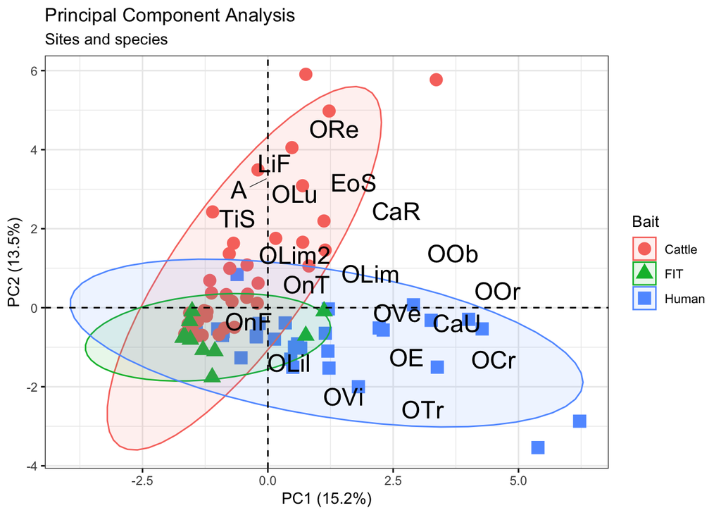

```r
new.pca<-PCA(commatrix[-c(5, 82), -c(1,2)], scale.unit = TRUE, ncp = 5, graph = F)
eig.val <- get_eigenvalue(new.pca)

fviz_pca_biplot(new.pca,
                col.ind = commatrix$Bait.Type[-c(5, 82)],
                repel = T,
                mean.point = F,
                geom.ind = "point",
                pointsize = 4,
                geom.var = "text",
                col.var = "black",
                legend.title = list(colour = "Bait", shape = "Bait", fill = "Bait"),
                labelsize = 6,
                addEllipses = TRUE,
                title = "Principal Component Analysis",
              subtitle = "Sites and species",
              xlab = "PC1 (15.2%)", ylab = "PC2 (13.5%)",
              ggtheme = theme_bw())
```

```r
# contributions of each species
options(scipen=999)
new.pca$var$contrib
```

```
##               Dim.1        Dim.2       Dim.3        Dim.4           Dim.5
## CaR    3.6970581031  5.640838803  0.75046974  6.834601177  0.109683924950
## EoS    1.3149891361 13.468612736  2.63042998  5.986706623  1.235098084510
## LiF    0.2579716788 17.399658638 10.48093202  2.939437355  0.057137024754
## OnT    0.1520294099  0.064380767 26.41309762  0.049895412  2.226772918519
## TiS    0.0171970037  4.393451735  0.98881963 11.904033575 13.434666627496
## CaU   16.6165331253  0.001473373  5.41532112  7.370280729  5.795141955124
## OLil   0.0026924218  1.166341509  0.29028973  0.381428641 21.222762286233
## OLu    0.0249742647  6.902607393  0.01519994 22.065355771  0.508566184152
## OLim   2.3312931228  0.275132580  5.23517828  2.005408007  0.839068793852
## OLim2  0.0266616007  3.081885798  0.35337489 19.418191349  2.083898101418
## OVe    4.6828232860  0.253458607 32.59893184  0.003291711  0.318087801124
## OE     5.5150578649  2.839825968  0.29957026  0.066220868 18.624941775847
## OVi    3.4257182693  3.921711617  0.34027187  2.013498301 23.226319193310
## OCr   16.4320140446  2.987822564  1.30964391  0.579663381  2.213743251398
## OOb   16.0131762930  1.134196710  0.18187241  7.340688412  0.290212946574
## OOr   17.0378683658  0.669586928  5.21295417  0.087921187  5.523229838426
## OTr   11.5862269334  5.349793846  7.11520768  0.004178500  1.656193892350
## ORe    0.8648841412 18.896909541  0.05536002 10.920387525  0.634465895149
## OnF    0.0000000000  0.000000000  0.00000000  0.000000000  0.000000000000
## A      0.0008309348 11.552310886  0.31307488  0.028811475  0.000009504813
```

```r
new.pca$ind$contrib
```

```
##           Dim.1         Dim.2          Dim.3            Dim.4
## 1   6.519285155  0.0392318127  0.00155318520  1.4846708765162
## 2   1.326336294  1.8260174038  0.32459493188  0.5323724270571
## 3   0.333209431  0.2247439092  0.01921914551  0.0104797338193
## 4   0.174333318  0.4766687127  0.75023632342  0.3725063789930
## 6   2.151827053  0.1456438365  0.77547739145  0.1108264842541
## 7   2.005964674  0.1203306673  0.04772995347  0.0907227538632
## 8  15.725146421  3.7693565938  1.98920597608  2.6940904284409
## 9   0.592056689  0.0004092383  0.06387172298  1.3379996148517
## 10  0.604405319  1.0667601856  0.00023865629  0.0881700942449
## 11  0.021208005  0.2331811514  0.00172189587  0.0174848994034
## 12  0.406398587  0.1311195266  0.21492042077  0.0001885582048
## 13  0.152890592  0.3242651130  0.19695849626  7.4475396910818
## 14  0.012206108  0.0720432658  0.53888445095  0.0004012804504
## 15  0.830181946  0.1801614542  0.07853329205  0.0063740116355
```

[output cut: 157 more lines]

```r
head(new.pca$eig, n=10)
```

```
##         eigenvalue percentage of variance
## comp 1   2.8947608              15.235583
## comp 2   2.5733868              13.544141
## comp 3   2.0351471              10.711300
## comp 4   1.7117086               9.008993
## comp 5   1.2964507               6.823425
## comp 6   1.1793395               6.207050
## comp 7   1.0242729               5.390910
## comp 8   1.0038125               5.283224
## comp 9   0.8572037               4.511598
## comp 10  0.7951066               4.184772
##         cumulative percentage of variance
## comp 1                           15.23558
## comp 2                           28.77972
## comp 3                           39.49102
## comp 4                           48.50002
## comp 5                           55.32344
## comp 6                           61.53049
## comp 7                           66.92140
## comp 8                           72.20463
## comp 9                           76.71622
## comp 10                          80.90100
```

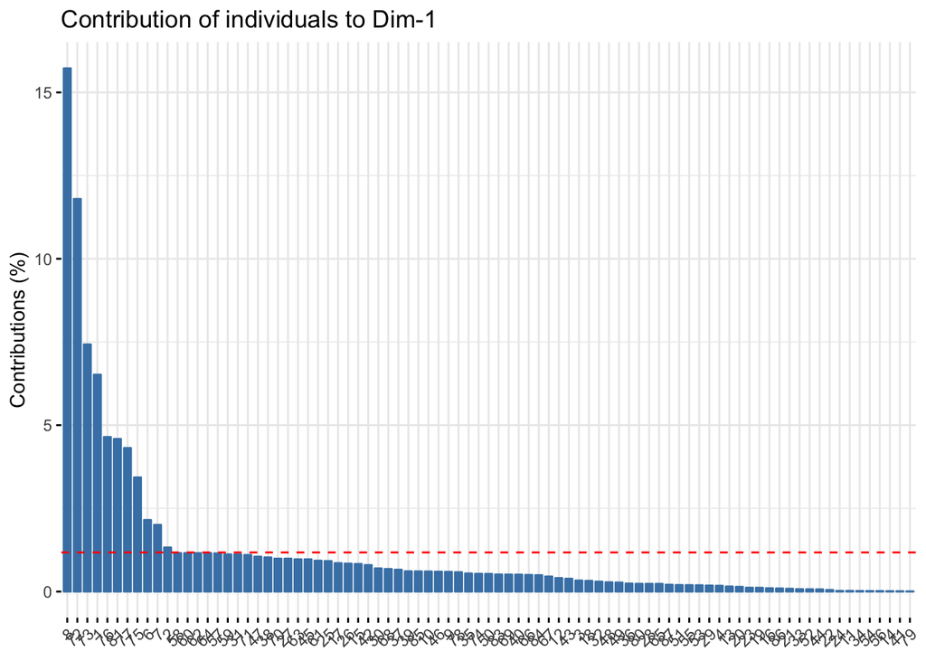

```r
fviz_contrib(new.pca, choice = "ind", axes = 1)
```

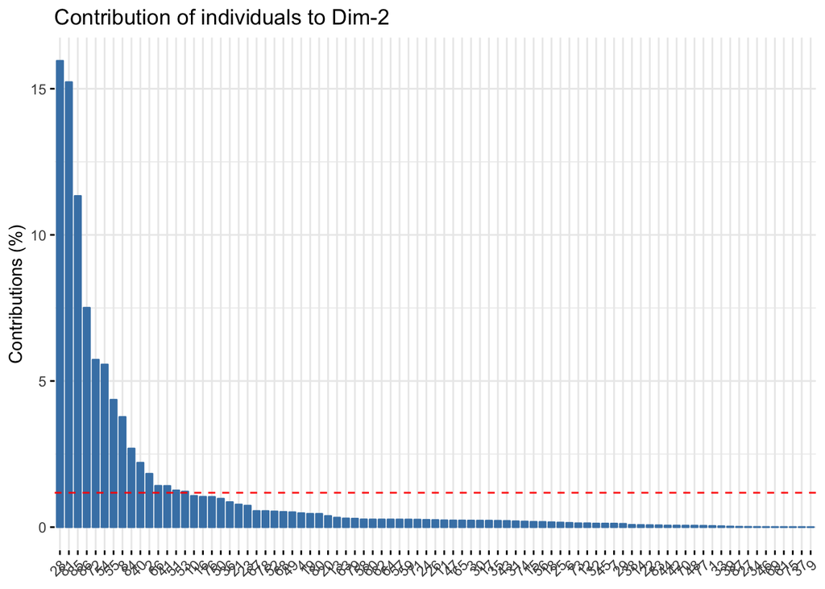

```r
fviz_contrib(new.pca, choice = "ind", axes = 2)
```

```r
#fviz_contrib(new.pca, choice = "var", axes = 1, fill = as.numeric(commatrix$Bait.Type[-c(5, 82)]), sort.val = "none")
#fviz_contrib(new.pca, choice = "var", axes = 2, fill = as.numeric(commatrix$Bait.Type[-c(5, 82)]), sort.val = "none")
```

# Concluding remarks

I think this marks the end of the analysis. I believe the paper would benefit from being paired down by omitting the bait experiment and just having these analyses and graphs in the final paper. If there is anything that I have missed out, or any suggestions I will welcome them! I am at the moment writing the manuscript and I think it’s shaping up. A lot is being cut out, which is a good thing.

I hope to send the manuscript soon.

Many thanks, Max